# Lab 10: Distances and the Border Zone

ESS 330

Author

Sarah Culhane

```r
# spatial data science
library(tidyverse)
library(sf)
library(units)
# Data
library(AOI)

# Visualization
library(gghighlight)
library(ggrepel)
library(knitr)
library(flextable)
```

First, I loaded the necessary libraries.

# Question 1

1.1

```r
# Define Projection
eqdc <- '+proj=eqdc +lat_0=40 +lon_0=-96 +lat_1=20 +lat_2=60 +x_0=0 +y_0=0 +datum=NAD83 +units=m +no_defs'
```

First, I downloaded a projection that preserves distance at the scale of CONUS.

1.2 - Get USA state boundaries

```r
states <- aoi_get(state = 'conus') %>%
  st_transform(crs = eqdc)
```

Then, I installed the correct github AOI package to get USA state borders and used st_transform reproject the data to the correct coordinate system (eqdc)

1.3 - Get country boundaries for Mexico, the U.S., and Canada

```r
countries <- aoi_get(country = c("MX", "CA", "USA")) %>%
  st_transform(crs = eqdc)
```

Then, I used aoi_get() to access country boundaries, making sure the data is in the correct projected coordinate system (eqdc)

1.4 - Get city locations from the CSV file

```r
library(readr)
library(dplyr)
# load libraries

cities_df <- read_csv("data/uscities.csv") #read data into working session
cities <- st_as_sf(cities_df,
                   coords = c("lng", "lat"),
                   crs = 4326) %>%
  st_transform(crs = eqdc)
states_list <- unique(states$state_abbr)
cities <- cities %>% filter(state_id %in% states_list) #filter cities outside of the U.S., Canada, or Mexico
```

Then, I converted the “uscities” dataframe to a spatial object. and removed the cities in states that I do not want using the filter() function

# Question 2

2.1 - distance to USA border (coastline or national) (km)

```r
usa_border <- states %>%
  st_union() %>%
  st_cast("MULTILINESTRING") # convert the state boundaries to a MULTILINESTRING geometry using the state object

cities$dist_to_border_km <- as.numeric(st_distance(cities, usa_border)) / 1000

top5_border <- cities %>%
  arrange(desc(dist_to_border_km)) %>%
  select(city, state_id, dist_to_border_km) %>%
  slice_head(n = 5)

flextable(top5_border)
```

| city | state_id | dist_to_border_km | geometry |
| --- | --- | --- | --- |
| Minneapolis | KS | 1,084.275 | [[XY]] |
| Ada | KS | 1,084.112 | [[XY]] |
| Barnard | KS | 1,083.737 | [[XY]] |
| Manchester | KS | 1,080.210 | [[XY]] |
| Talmage | KS | 1,080.049 | [[XY]] |

Using the code above, i produced a table documenting the five cities farthest from the USA border.

2.2

```r
state_borders <- states %>%
  st_combine() %>%
  st_cast("MULTILINESTRING") # convert the USA state boundaries to a MULTILINESTRING geometry

cities$dist_to_state_km <- as.numeric(st_distance(cities, state_borders)) / 1000

top5_state <- cities %>%
  arrange(desc(dist_to_state_km)) %>%
  select(city, state_id, dist_to_state_km) %>%
  slice_head(n = 5)

flextable(top5_state)
```

| city | state_id | dist_to_state_km | geometry |
| --- | --- | --- | --- |
| Briggs | TX | 314.7901 | [[XY]] |
| Lampasas | TX | 308.9002 | [[XY]] |
| Florence | TX | 304.0898 | [[XY]] |
| Salado | TX | 302.8041 | [[XY]] |
| Kempner | TX | 302.5260 | [[XY]] |

I used the code above to document the five cities farthest from a state border.

2.3

```r
mexico <- countries %>%
  filter(postal == "MX") %>%
  st_cast("MULTILINESTRING")

cities$dist_to_mexico_km <- as.numeric(st_distance(cities, mexico)) / 1000

top5_mexico <- cities %>%
  arrange(desc(dist_to_mexico_km)) %>%
  select(city, state_id, dist_to_mexico_km) %>%
  slice_head(n = 5)

flextable(top5_mexico)
```

| city | state_id | dist_to_mexico_km | geometry |
| --- | --- | --- | --- |
| Grand Isle | ME | 3,282.825 | [[XY]] |
| Caribou | ME | 3,250.330 | [[XY]] |
| Presque Isle | ME | 3,234.570 | [[XY]] |
| Oakfield | ME | 3,175.577 | [[XY]] |
| Island Falls | ME | 3,162.285 | [[XY]] |

I used the code above to produce a table documenting the five cities farthest from the Mexico border.

2.4

```r
canada <- countries %>%
  filter(postal == "CA") %>%
  st_cast("MULTILINESTRING")

cities$dist_to_canada_km <- as.numeric(st_distance(cities, canada)) / 1000

top5_canada <- cities %>%
  arrange(desc(dist_to_canada_km)) %>%
  select(city, state_id, dist_to_canada_km) %>%
  slice_head(n = 5)

flextable(top5_canada)
```

| city | state_id | dist_to_canada_km | geometry |
| --- | --- | --- | --- |
| Guadalupe Guerra | TX | 2,206.455 | [[XY]] |
| Sandoval | TX | 2,205.641 | [[XY]] |
| Fronton | TX | 2,204.794 | [[XY]] |
| Fronton Ranchettes | TX | 2,202.118 | [[XY]] |
| Evergreen | TX | 2,202.020 | [[XY]] |

I used the code above to produce a table documenting the top five cities farthest away from the Canada border.

# Question 3

```r
library(ggrepel)
library(gghighlight)
library(viridis)
# load neccessary libraries
```

3.1 Data

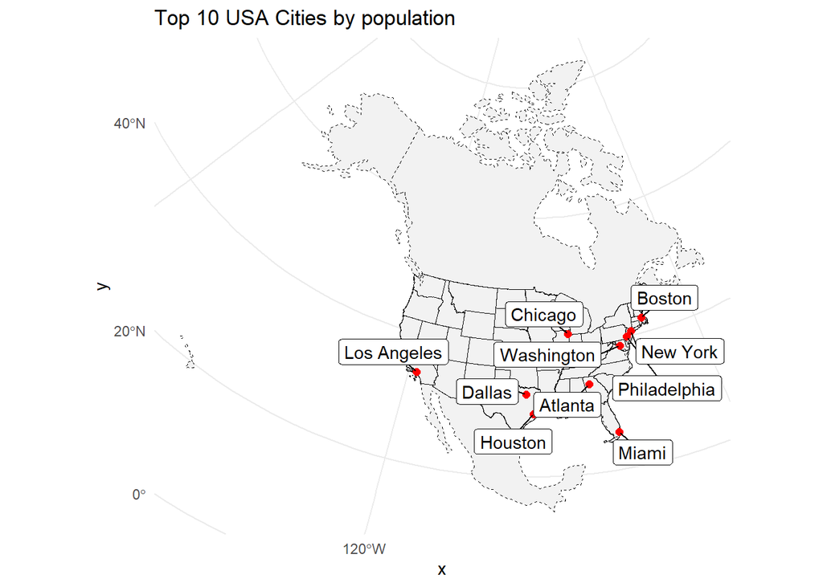

```r
# Top 10 cities by population
top10_cities <- cities %>%
  arrange(desc(population)) %>%
  slice_head(n = 10)

# create a map
ggplot() +
  geom_sf(data = countries, fill = "gray95", color = "black", size = 0.5, lty = 2) +
  geom_sf(data = states, fill = NA, color = "black", size = 0.3) +
  geom_sf(data = top10_cities, color = "red", size = 2) +
  ggrepel::geom_label_repel(data = top10_cities,
                            aes(label = city, geometry = geometry),
                            stat = "sf_coordinates",
                            min.segment.length = 0,
                             max.overlaps = 20) +
  theme_minimal() +
  labs(title = "Top 10 USA Cities by population")
```

I used the code above to create a map of the 10 largest USA cities (by population) on a single map.

3.2

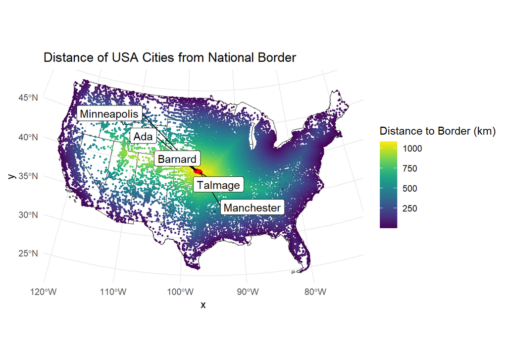

```r
# 5 farthest from national border
top5_border_cities <- cities %>%
  arrange(desc(dist_to_border_km)) %>%
  slice_head(n = 5)

ggplot() +
  geom_sf(data = states, fill = NA, color = "black", size = 0.3) +
  geom_sf(data = cities, aes(color = dist_to_border_km), size = 0.5) +
  scale_color_viridis(name = "Distance to Border (km)", option = "viridis") +
  geom_sf(data = top5_border_cities, color = "red", size = 2) +
  ggrepel::geom_label_repel(data = top5_border_cities,
                            aes(label = city, geometry = geometry),
                            stat = "sf_coordinates",
                            min.segment.length = 0) +
  theme_minimal() +
  labs(title = "Distance of USA Cities from National Border")
```

I used the code above to create map that colors USA cities by their distance from the national border and labels the 5 cities that are farthest from the border.

3.3 - City Distance from Nearest State

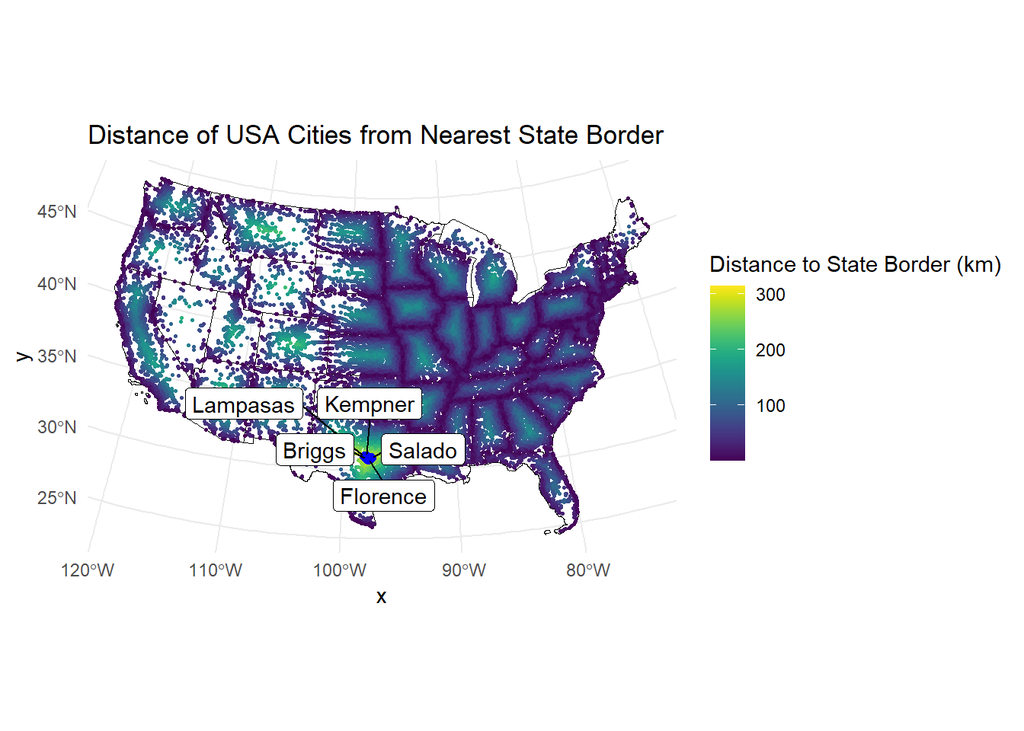

```r
# 5 farthest from state border
top5_state_cities <- cities %>%
  arrange(desc(dist_to_state_km)) %>%
  slice_head(n = 5)

ggplot() +
  geom_sf(data = states, fill = NA, color = "black", size = 0.3) +
  geom_sf(data = cities, aes(color = dist_to_state_km), size = 0.5) +
  scale_color_viridis(name = "Distance to State Border (km)", option = "viridis") +
  geom_sf(data = top5_state_cities, color = "blue", size = 2) +
  ggrepel::geom_label_repel(data = top5_state_cities,
                            aes(label = city, geometry = geometry),
                            stat = "sf_coordinates",
                            min.segment.length = 0) +
  theme_minimal() +
  labs(title = "Distance of USA Cities from Nearest State Border")
```

I used the code above to create a map that colors USA cities by their distance from the nearest state border and labeled the 5 cities that re farthest away from any border.

3.4 Equidistance boundary from Mexico and Canada

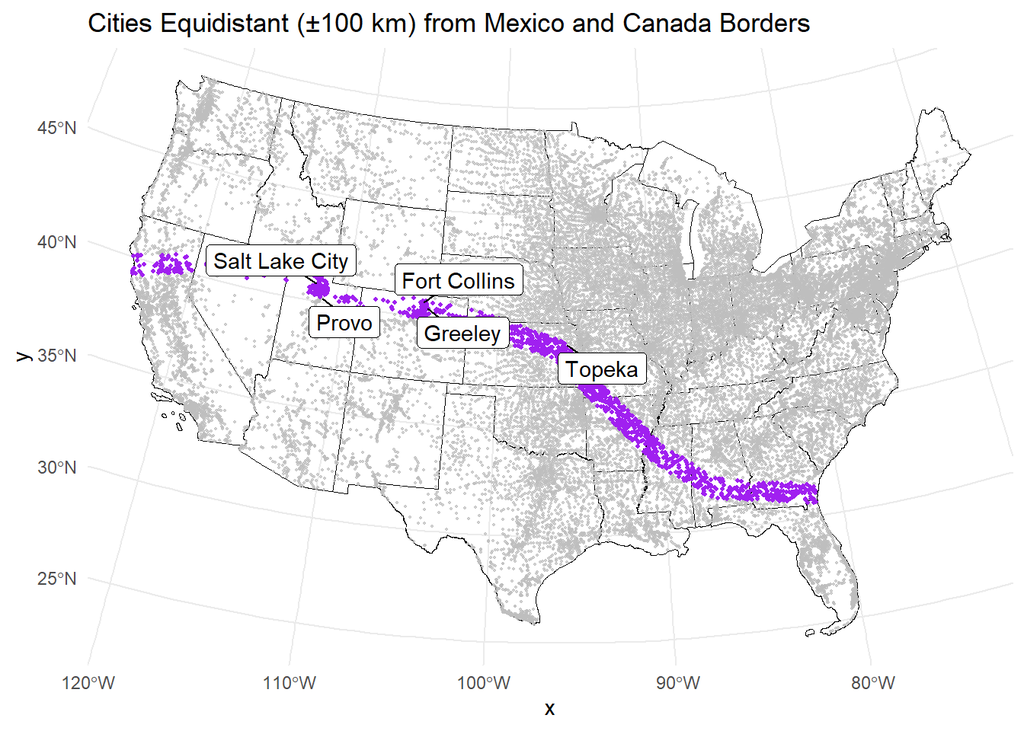

```r
cities <- cities %>%
  mutate(abs_diff_mex_can = abs(dist_to_mexico_km - dist_to_canada_km))

equidistant_cities <- cities %>%
  filter(abs_diff_mex_can <= 100)

top5_equidistant <- equidistant_cities %>%
  arrange(desc(population)) %>%
  slice_head(n = 5)

ggplot() +
  geom_sf(data = states, fill = NA, color = "black", size = 0.3) +
  geom_sf(data = cities, color = "lightgray", size = 0.3) +
  geom_sf(data = equidistant_cities, aes(geometry = geometry), color = "purple", size = 0.8) +
  gghighlight(abs_diff_mex_can <= 100, label_key = city) +
  ggrepel::geom_label_repel(data = top5_equidistant,
                            aes(label = city, geometry = geometry),
                            stat = "sf_coordinates",
                            min.segment.length = 0,
                            max.overlaps = Inf) +
  theme_minimal() +
  labs(title = "Cities Equidistant (±100 km) from Mexico and Canada Borders")
```

I used the code above to identify the cities that are equal distrance from the Canadian AND Mexican border (+/- 100 km).

# Question 4

4.1 Quantifying Border Zone

```r
total_population <- sum(cities$population, na.rm = TRUE)
```

```r
border_zone_cities <- cities %>%
  filter(dist_to_border_km <= 160)
border_zone_population <- sum(border_zone_cities$population, na.rm = TRUE)
percent_in_zone <- (border_zone_population / total_population) * 100
library(tibble)

border_zone_summary <- tibble(
  Metric = c(
    "Number of Cities within 100 miles",
    "Population within 100 miles",
    "Percent of Total Population in Zone"
  ),
  Value = c(
    nrow(border_zone_cities),
    border_zone_population,
    round(percent_in_zone, 2)
  )
)

border_zone_summary
```

```
# A tibble: 3 × 2
  Metric                                    Value
  <chr>                                     <dbl>
1 Number of Cities within 100 miles        9813
2 Population within 100 miles         216043045
3 Percent of Total Population in Zone        54.5
```

I used the code above to create a table reporting how many cities are in the 100 mile zone, how many people live in a city within 100 miles of the border, and what percentage of the total population is in this zone. However, I could not find the ACLU estimates using the article provided.

4.2 - Mapping Border Zonee

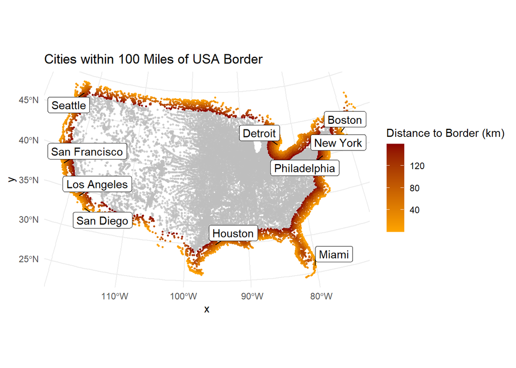

```r
ggplot() +
  geom_sf(data = cities, aes(color = dist_to_border_km), size = 0.5) +
  scale_color_gradient(low = "orange", high = "darkred") +
  gghighlight(dist_to_border_km <= 160, label_key = city) +
  ggrepel::geom_label_repel(
    data = border_zone_cities %>%
      top_n(10, population),
    aes(label = city, geometry = geometry),
    stat = "sf_coordinates",
    min.segment.length = 0,
    max.overlaps = Inf
  ) +
  theme_minimal() +
  labs(title = "Cities within 100 Miles of USA Border",
       color = "Distance to Border (km)")
```

I used the code above to make a map highlighting the cities within the 100 mile zone and label the top 10 most populous cities

4.3

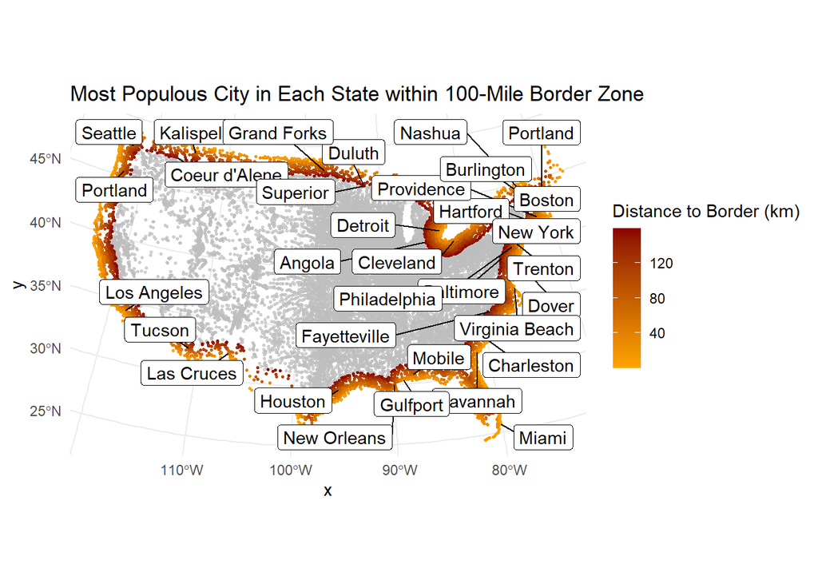

```r
library(dplyr)

top_city_per_state <- border_zone_cities %>%
  group_by(state_name) %>%
  slice_max(order_by = population, n = 1) %>%
  ungroup()
ggplot() +
  geom_sf(data = cities, aes(color = dist_to_border_km), size = 0.5) +
  scale_color_gradient(low = "orange", high = "darkred") +
  gghighlight(dist_to_border_km <= 160, label_key = city) +
  ggrepel::geom_label_repel(
    data = top_city_per_state,
    aes(label = city, geometry = geometry),
    stat = "sf_coordinates",
    min.segment.length = 0,
    max.overlaps = Inf
  ) +
  theme_minimal() +
  labs(title = "Most Populous City in Each State within 100-Mile Border Zone",
       color = "Distance to Border (km)")
```

I used the code above to label the most populous city in each state within the danger zone.